# SLF_Project_TemplateNotebook

## Importing necessary libraries and data

```python
#by Narges Shahmohammadi
import numpy as np
import pandas as pd
import matplotlib.pyplot as plt
import seaborn as sns
sns.set()
from sklearn.model_selection import train_test_split

from sklearn.linear_model import LinearRegression
from sklearn.metrics import mean_absolute_error, mean_squared_error, r2_score
import statsmodels.api as sm

df = pd.read_csv("used_phone_data.csv")
```

## Data Overview

- Observations
- Sanity checks

```python
df.head()
```

|  | brand_name | os | screen_size | 4g | 5g | main_camera_mp | selfie_camera_mp | int_memory | ram | battery | weight | release_year | days_used | new_price | used_price |
| --- | --- | --- | --- | --- | --- | --- | --- | --- | --- | --- | --- | --- | --- | --- | --- |
| 0 | Honor | Android | 23.97 | yes | no | 13.0 | 5.0 | 64.0 | 3.0 | 3020.0 | 146.0 | 2020 | 127 | 111.62 | 86.96 |
| 1 | Honor | Android | 28.10 | yes | yes | 13.0 | 16.0 | 128.0 | 8.0 | 4300.0 | 213.0 | 2020 | 325 | 249.39 | 161.49 |
| 2 | Honor | Android | 24.29 | yes | yes | 13.0 | 8.0 | 128.0 | 8.0 | 4200.0 | 213.0 | 2020 | 162 | 359.47 | 268.55 |
| 3 | Honor | Android | 26.04 | yes | yes | 13.0 | 8.0 | 64.0 | 6.0 | 7250.0 | 480.0 | 2020 | 345 | 278.93 | 180.23 |
| 4 | Honor | Android | 15.72 | yes | no | 13.0 | 8.0 | 64.0 | 3.0 | 5000.0 | 185.0 | 2020 | 293 | 140.87 | 103.80 |

```python
df.shape
```

```
(3571, 15)
```

#### there are 3571 rows and 15 columns in our data

```python
#check the type of variables
df.info()
```

```
<class 'pandas.core.frame.DataFrame'>
RangeIndex: 3571 entries, 0 to 3570
Data columns (total 15 columns):
 #   Column            Non-Null Count  Dtype
---  ------            --------------  -----
 0   brand_name        3571 non-null   object
 1   os                3571 non-null   object
 2   screen_size       3571 non-null   float64
 3   4g                3571 non-null   object
 4   5g                3571 non-null   object
 5   main_camera_mp    3391 non-null   float64
 6   selfie_camera_mp  3569 non-null   float64
 7   int_memory        3561 non-null   float64
 8   ram               3561 non-null   float64
 9   battery           3565 non-null   float64
 10  weight            3564 non-null   float64
 11  release_year      3571 non-null   int64
 12  days_used         3571 non-null   int64
 13  new_price         3571 non-null   float64
 14  used_price        3571 non-null   float64
dtypes: float64(9), int64(2), object(4)
memory usage: 418.6+ KB
```

#### There are some missing data in the database, so let's ckeck them out

#### 4 columns need to change their type: brand_name/os /4g/5g

#### we also have `release_year` which is date column but for now I don't think that it needs any change

```python
df.isnull().sum().sort_values(ascending= False)
```

```
main_camera_mp      180
int_memory           10
ram                  10
weight                7
battery               6
selfie_camera_mp      2
brand_name            0
os                    0
screen_size           0
4g                    0
5g                    0
release_year          0
days_used             0
new_price             0
used_price            0
dtype: int64
```

#### it seems we have null in some columns ! main_camera_mp has the highest amount of null = 180

```python
pd.set_option(
    "display.float_format", lambda x: "%.3f" % x)
df.describe(include="all").T
```

|  | count | unique | top | freq | mean | std | min | 25% | 50% | 75% | max |
| --- | --- | --- | --- | --- | --- | --- | --- | --- | --- | --- | --- |
| brand_name | 3571 | 34 | Others | 509 | NaN | NaN | NaN | NaN | NaN | NaN | NaN |
| os | 3571 | 4 | Android | 3246 | NaN | NaN | NaN | NaN | NaN | NaN | NaN |
| screen_size | 3571.000 | NaN | NaN | NaN | 14.804 | 5.153 | 2.700 | 12.700 | 13.490 | 16.510 | 46.360 |
| 4g | 3571 | 2 | yes | 2359 | NaN | NaN | NaN | NaN | NaN | NaN | NaN |
| 5g | 3571 | 2 | no | 3419 | NaN | NaN | NaN | NaN | NaN | NaN | NaN |
| main_camera_mp | 3391.000 | NaN | NaN | NaN | 9.400 | 4.818 | 0.080 | 5.000 | 8.000 | 13.000 | 48.000 |
| selfie_camera_mp | 3569.000 | NaN | NaN | NaN | 6.547 | 6.879 | 0.300 | 2.000 | 5.000 | 8.000 | 32.000 |
| int_memory | 3561.000 | NaN | NaN | NaN | 54.533 | 84.696 | 0.005 | 16.000 | 32.000 | 64.000 | 1024.000 |
| ram | 3561.000 | NaN | NaN | NaN | 4.057 | 1.392 | 0.030 | 4.000 | 4.000 | 4.000 | 16.000 |
| battery | 3565.000 | NaN | NaN | NaN | 3067.226 | 1364.207 | 80.000 | 2100.000 | 3000.000 | 4000.000 | 12000.000 |
| weight | 3564.000 | NaN | NaN | NaN | 179.424 | 90.281 | 23.000 | 140.000 | 159.000 | 184.000 | 950.000 |
| release_year | 3571.000 | NaN | NaN | NaN | 2015.965 | 2.292 | 2013.000 | 2014.000 | 2016.000 | 2018.000 | 2020.000 |
| days_used | 3571.000 | NaN | NaN | NaN | 675.391 | 248.641 | 91.000 | 536.000 | 690.000 | 872.000 | 1094.000 |
| new_price | 3571.000 | NaN | NaN | NaN | 237.389 | 197.546 | 9.130 | 120.130 | 189.800 | 291.935 | 2560.200 |
| used_price | 3571.000 | NaN | NaN | NaN | 109.880 | 121.501 | 2.510 | 45.205 | 75.530 | 126.000 | 1916.540 |

```python
df['os'].value_counts()
```

```
Android    3246
Others      202
Windows      67
iOS          56
Name: os, dtype: int64
```

Android in the data has the most amount

## Exploratory Data Analysis (EDA)

- EDA is an important part of any project involving data.
- It is important to investigate and understand the data better before building a model with it.
- A few questions have been mentioned below which will help you approach the analysis in the right manner and generate insights from the data.
- A thorough analysis of the data, in addition to the questions mentioned below, should be done.

**Questions**:

1. What does the distribution of used phone prices look like?
2. What percentage of the used phone market is dominated by Android devices?
3. The amount of RAM is important for the smooth functioning of a phone. How does the amount of RAM vary with the brand?
4. A large battery often increases a phone's weight, making it feel uncomfortable in the hands. How does the weight vary for phones offering large batteries (more than 4500 mAh)?
5. Bigger screens are desirable for entertainment purposes as they offer a better viewing experience. How many phones are available across different brands with a screen size larger than 6 inches?
6. Budget phones nowadays offer great selfie cameras, allowing us to capture our favorite moments with loved ones. What is the distribution of budget phones offering greater than 8MP selfie cameras across brands?
7. Which attributes are highly correlated with the used phone price?

## Univariate Data Analysis¶

#### since we will take a look to `used_price` later, now we start with `new_price`

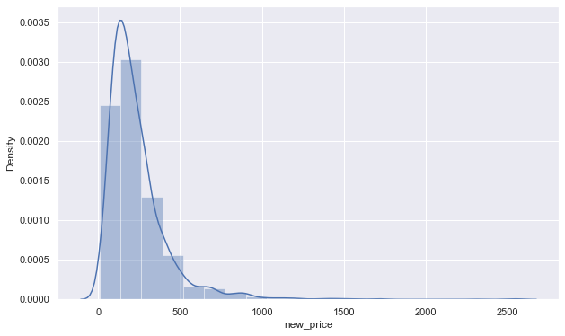

```python
plt.figure(figsize=(10,6))
sns.distplot(df.new_price,color="b",bins=20);
```

##### distribution of new_price is highly skewed to the right. As I showed in above table its mean is 237.38

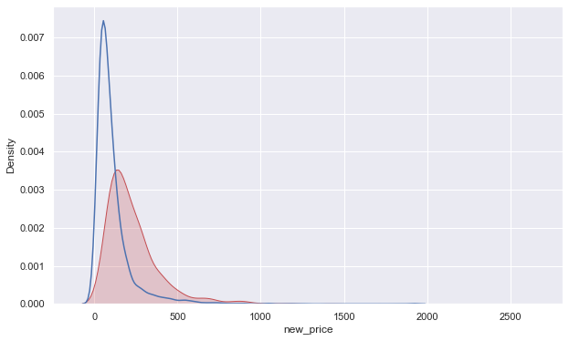

```python
plt.figure(figsize=(10,6))
# plotting both distibutions on the same figure
fig = sns.kdeplot(df['new_price'], shade=True, color="r")
fig = sns.kdeplot(df['used_price'], shade=False, color="b")

plt.show();
```

#### showing differnce between new price and used price. both have a highly right skewed distribution.

#### the red one is for new price and as I expected it is higher than the used one.

#### the mean of used_price is 109.88 € which is much lower than the new_price(237.38€)

```python
def histogram_boxplot(df, feature, figsize=(12, 7), kde=False, bins=None):
    """
    Boxplot and histogram combined

    data: dataframe
    feature: dataframe column
    figsize: size of figure (default (12,7))
    kde: whether to the show density curve (default False)
    bins: number of bins for histogram (default None)
    """
    f2, (ax_box2, ax_hist2) = plt.subplots(
        nrows=2,
        sharex=True,
        gridspec_kw={"height_ratios": (0.25, 0.75)},
        figsize=figsize,
    )
    sns.boxplot(
        data=df, x=feature, ax=ax_box2, showmeans=True, color="y")
    sns.histplot(
        data=df, x=feature, kde=kde, ax=ax_hist2, bins=bins, palette="winter"
    ) if bins else sns.histplot(
        data=df, x=feature, kde=kde, ax=ax_hist2)
    ax_hist2.axvline(
        df[feature].mean(), color="green", linestyle="--")
    ax_hist2.axvline(
        df[feature].median(), color="black", linestyle="-")
```

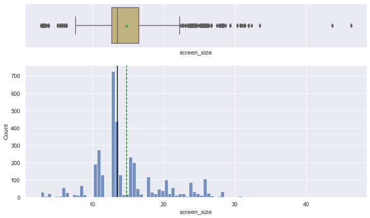

```python
histogram_boxplot(df, "screen_size")
```

#### distribution of screen_size skewed to the right and its mean is 14.80 cm. we can see outlieres in its boxplot

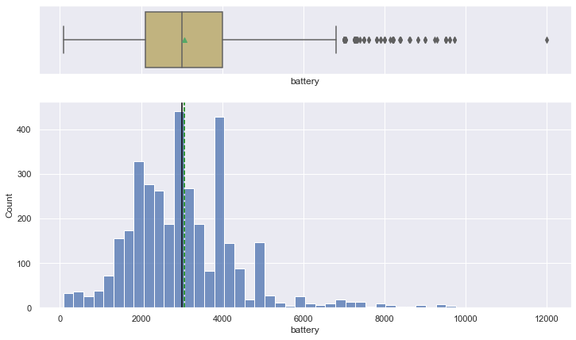

```python
histogram_boxplot(df, "battery")
```

#### distribution of battery is `not` look like a normal distriboution! also seems that it has outliers and its mean is 3067.22

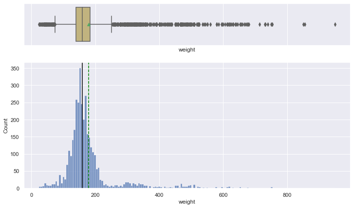

```python
histogram_boxplot(df, "weight")
```

#### column weight distribution is very skewed to the right which means some cell phones are very heavy.

#### the mean of cell phons's weight is around 179 grams

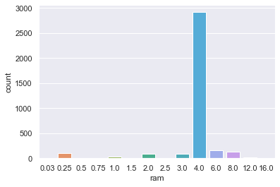

```python
sns.countplot(data = df, x='ram')
plt.show()
```

#### take a look at column ram by bar plot. ram of 4.0 GB is higher than others ( its count is around 2900).

#### it is good to see each percentages of amount of RAM

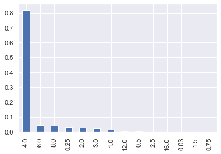

```python
(df['ram'].value_counts() / df['ram'].count()).plot(kind='bar')
```

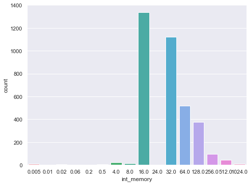

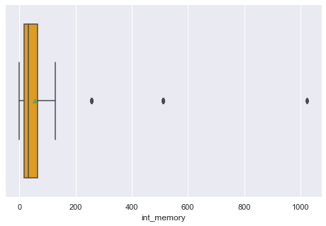

```python
#count plot and box plot for internal memory of cell phons.
plt.figure(figsize=(8,6))
sns.countplot(data = df, x='int_memory')

plt.figure(figsize=(8,5))
sns.boxplot(df['int_memory'], color='orange', showmeans=True);
```

#### most of cell phons have 16.0 GB internal memory and then it is 32.0 GB. we have some outliers which I think is better to get rid of them.

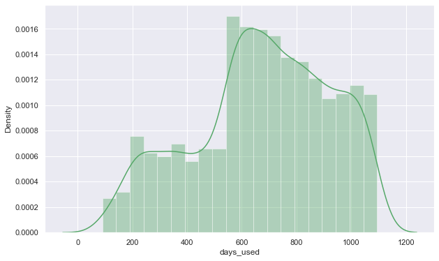

```python
#distribution of [days_used].with mean of 675.391
plt.figure(figsize=(10,6))
sns.distplot(df.days_used
             ,color="g",bins=20);
```

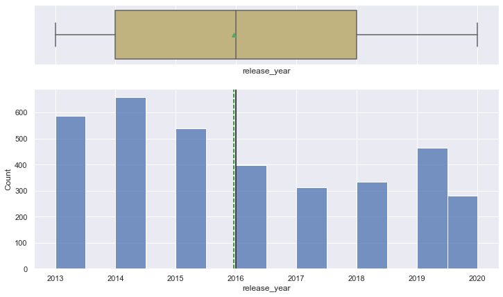

```python
histogram_boxplot(df, "release_year")
```

#### The `release_year` variable is not a normal distribution, mean and the median is 2016.

## Multivariate Data Analysis

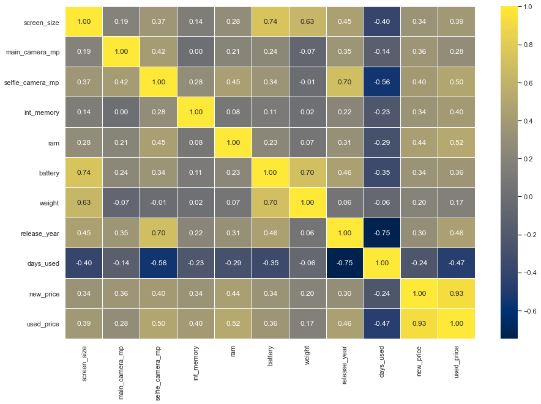

```python
fig,ax = plt.subplots(figsize=(15,10))
sns.heatmap(df.corr(), annot=True, linewidths=0.05, fmt= '.2f',cmap="cividis")
plt.show()
```

#### it seems that `new_price` and `used_price` are highly positive correlated(0.93) which I will show you in blow plot.

#### also between `used_price` and `days_used` are nagative relationship(-0.47)

[output not shown]

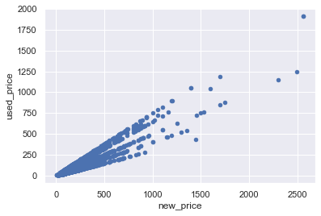

```python
df.plot.scatter(x='new_price', y='used_price');
```

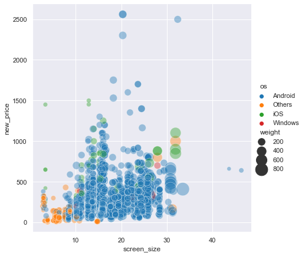

```python
plt.figure(figsize=(15,9))
sns.relplot(data = df, x='screen_size', y='new_price', hue='os',size='weight',sizes= (50,500),
            alpha= 0.4, palette='tab10',height= 6 );
```

#### By this plot we can see that most of the price of new phones are below 1000 euros and size of screen does not effect the price.

#### Also, bigest screen size are heavier. as I will mention later, Android is more popular

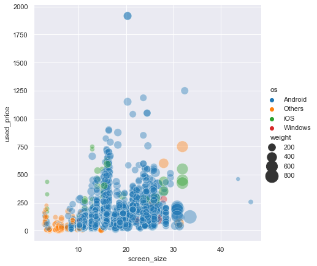

```python
plt.figure(figsize=(15,9))
sns.relplot(data = df, x='screen_size', y='used_price', hue='os',size='weight',sizes= (50,500),
            alpha= 0.4, palette='tab10',height= 6 );
```

#### the same plot but for `price of the used/refurbished` phone. most of them are below 500 euros and also bigger screen or heavier cell phone does not effect the price.

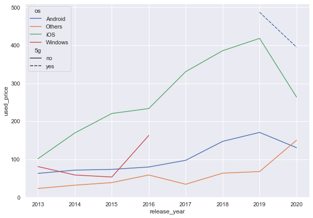

```python
plt.figure(figsize=(10,7))
sns.lineplot(data=df, x="release_year", y="used_price", hue="os",style="5g", ci=None);
```

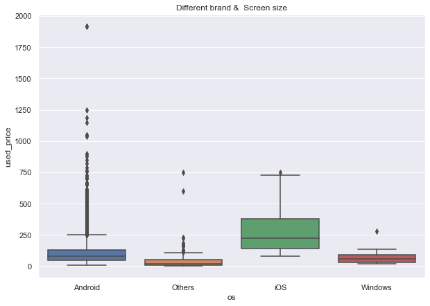

```python
plt.figure(figsize=(10,7))

ax = sns.boxplot(x="os", y="used_price",data=df)
plt.title("Different brand &  Screen size");
```

- Between differnt os, ios has the higher price and then it is Andriod.
- We can see lots of outliers especially in android category.

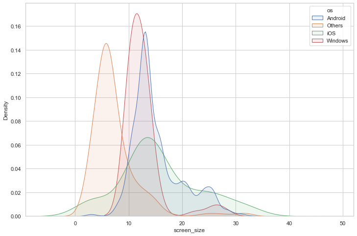

```python
# look at the screen size of different OS cellphons
plt.rcParams["figure.figsize"]=12,8
sns.set(style="whitegrid")
sns.kdeplot(data=df, x="screen_size", hue="os", fill=True, common_norm=False, alpha=.10)
plt.show()
```

- it seems that between different `os` ios has the biggest screen

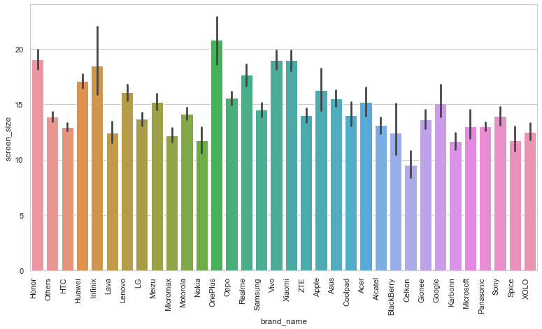

```python
plt.figure(figsize=(13,7))
chart8=sns.barplot(data = df, x='brand_name',y='screen_size',)
chart8.set_xticklabels(
    chart8.get_xticklabels(),
    rotation=90,
    horizontalalignment='right',
    fontweight='light');
```

- between cell phon brand `OnePluse` has the biggest screen and Celkon has smallest

### QUESTIONS

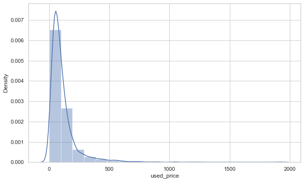

```python
#What does the distribution of used phone prices look like?
plt.figure(figsize=(10,6))
sns.distplot(df.used_price,color="b",bins=20);
```

### we have a normal distribution highly skewed to the right for used phone prices

```python
#What percentage of the used phone market is dominated by Android devices?

(df['os'].value_counts()/df['os'].value_counts().sum())[0]
```

```
0.9089890786894428
```

### around 90% of the used phone market is dominated by Android devices

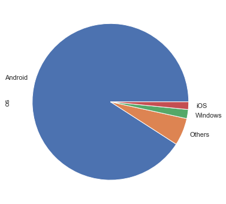

```python
#showing the same results by pie plot
plt.figure(figsize=(10,6))
df['os'].value_counts().plot(kind='pie');
```

```python
#How does the amount of RAM vary with the brand?

df.groupby('brand_name')['ram'].mean().sort_values(ascending= False)
```

```
brand_name
OnePlus      6.364
Oppo         4.961
Vivo         4.756
Huawei       4.641
Honor        4.593
Xiaomi       4.567
Google       4.533
Meizu        4.452
Realme       4.195
Samsung      4.159
Sony         4.068
Asus         4.048
ZTE          4.023
HTC          4.000
Panasonic    4.000
Apple        4.000
XOLO         4.000
Microsoft    4.000
Coolpad      3.955
Motorola     3.945
Gionee       3.933
Acer         3.902
LG           3.894
Lenovo       3.887
BlackBerry   3.830
Others       3.751
Micromax     3.750
Spice        3.750
Nokia        3.601
Alcatel      3.426
Karbonn      3.375
Lava         3.278
Infinix      2.600
Celkon       1.466
Name: ram, dtype: float64
```

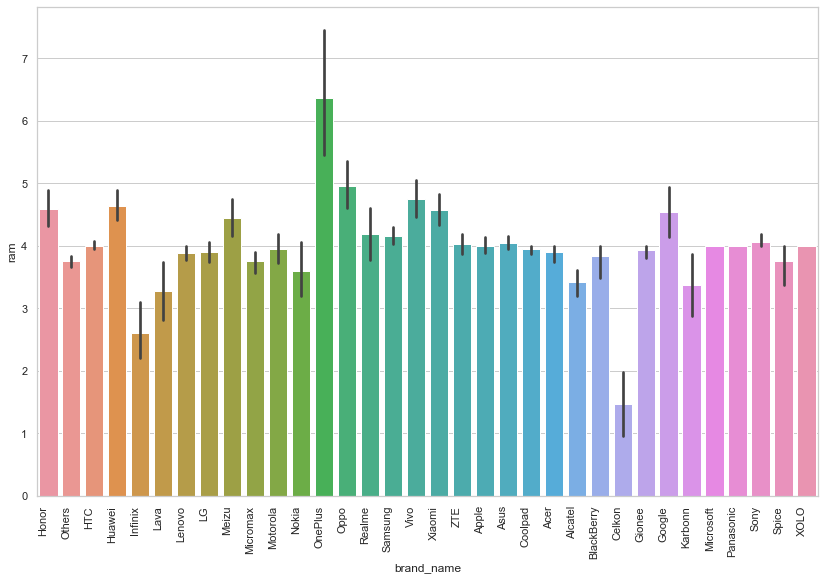

```python
#the same question in plot
plt.figure(figsize=(14,9))
chart=sns.barplot(data = df, x='brand_name',y='ram',)
chart.set_xticklabels(
   chart.get_xticklabels(),
   rotation=90,
    horizontalalignment='right',
    fontweight='light'
);
```

by this plot we can see each brand and their ram amount. brand **One plus**(around 6.5 GB) and then **Oppo** (around 5 GB) have the biggest ram and brand **Celkon** has been located in lowest location.(around 1.5 GB)

```python
#How does the weight vary for phones offering large batteries (more than 4500 mAh)?

#I started with filtering the data base on mAh>4500 and get their means
df2=df[df['battery']>4500]
df2.groupby('weight')['battery'].mean()
```

```
weight
23.000    12000.000
36.700     5493.000
48.000     5493.000
65.000     5700.000
118.000    4800.000
             ...
740.000    9500.000
750.000    9500.000
753.000    9500.000
855.000    8380.000
950.000    9600.000
Name: battery, Length: 175, dtype: float64
```

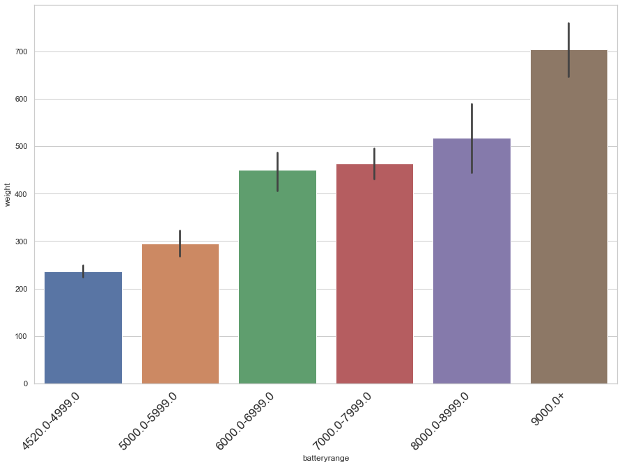

```python
# for best understanding I categorized battery column to 6 groups and then got a bar plot
bins = [4000.0, 5000.0, 6000.0, 7000.0, 8000.0, 9000.0, 10000.0]
labels = ['4520.0-4999.0','5000.0-5999.0','6000.0-6999.0','7000.0-7999.0','8000.0-8999.0','9000.0+']
df2['batteryrange'] = pd.cut(df2.battery,bins, labels = labels,include_lowest = True)
plt.figure(figsize=(15,10))
chart=sns.barplot(data = df2, x='batteryrange',y='weight',)
chart.set_xticklabels(
    chart.get_xticklabels(),
    rotation=45,
    horizontalalignment='right',
    fontweight='light',
    fontsize='x-large');
```

#### cellphones with highest weight have larger batteries

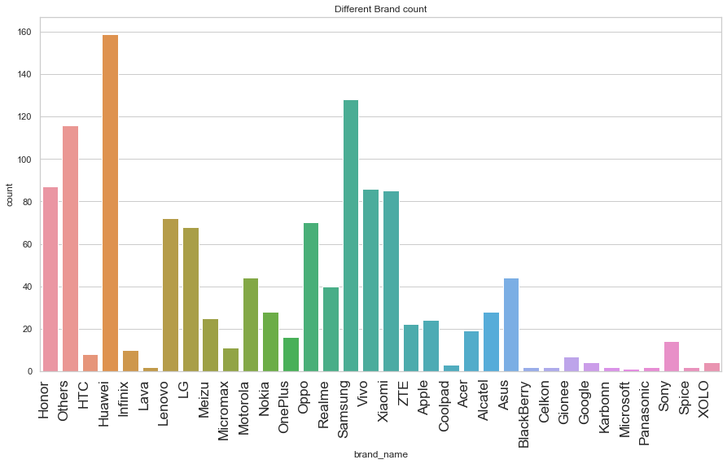

```python
#How many phones are available across different brands with a screen size larger than 6 inches?

#since our valuse in screen_size column is in centimeters, I needed to convert inche to cm : 6 inches is equal to 15.24 cm

df3=df[df['screen_size']>15.24]
plt.figure(figsize=(15,8))
c=sns.countplot(data = df3, x='brand_name')
c.set_xticklabels(
    c.get_xticklabels(),
    rotation=90,
    horizontalalignment='right',
    fontweight='light',
    fontsize='x-large')
plt.title("Different Brand count")
plt.show()
```

```python
df3['brand_name'].value_counts()
```

```
Huawei        159
Samsung       128
Others        116
Honor          87
Vivo           86
Xiaomi         85
Lenovo         72
Oppo           70
LG             68
Motorola       44
Asus           44
Realme         40
Alcatel        28
Nokia          28
Meizu          25
Apple          24
ZTE            22
Acer           19
OnePlus        16
Sony           14
Micromax       11
Infinix        10
HTC             8
Gionee          7
XOLO            4
Google          4
Coolpad         3
Karbonn         2
Spice           2
Lava            2
Celkon          2
Panasonic       2
BlackBerry      2
Microsoft       1
Name: brand_name, dtype: int64
```

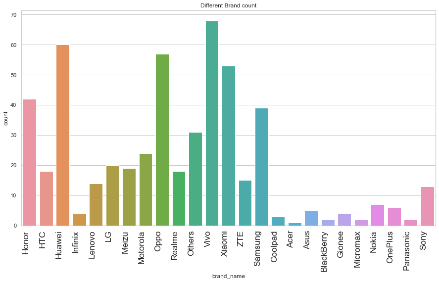

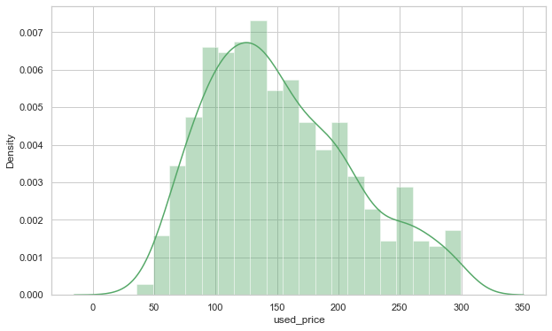

```python
# What is the distribution of budget phones offering greater than 8MP selfie cameras across brands?
df4 = df[(df["selfie_camera_mp"] > 8.0) & (df["used_price"] < 300.0)]# I assumed prices less than 300 Euros as a low-cost(budget)phone

plt.figure(figsize=(15,8))
c=sns.countplot(data = df4, x='brand_name')
c.set_xticklabels(
    c.get_xticklabels(),
    rotation=90,
    horizontalalignment='right',
    fontweight='light',
    fontsize='x-large')
plt.title("Different Brand count")

plt.figure(figsize=(10,6))
sns.distplot(df4.used_price
             ,color="g",bins=20);
```

- the distribution of budget phones offering greater than 8MP selfie cameras across brands is look like normal but skewed to the right
- also `Vivo`, `Huawei` and `Oppo` are on the top of this list which are offering greater than 8MP selfie cameras at a low price.

```python
#Which attributes are highly correlated with the used phone price?
df.corr()
```

|  | screen_size | main_camera_mp | selfie_camera_mp | int_memory | ram | battery | weight | release_year | days_used | new_price | used_price |
| --- | --- | --- | --- | --- | --- | --- | --- | --- | --- | --- | --- |
| screen_size | 1.000 | 0.189 | 0.370 | 0.144 | 0.283 | 0.742 | 0.635 | 0.455 | -0.397 | 0.342 | 0.386 |
| main_camera_mp | 0.189 | 1.000 | 0.424 | 0.004 | 0.207 | 0.240 | -0.073 | 0.354 | -0.143 | 0.360 | 0.281 |
| selfie_camera_mp | 0.370 | 0.424 | 1.000 | 0.283 | 0.445 | 0.345 | -0.005 | 0.697 | -0.556 | 0.399 | 0.498 |
| int_memory | 0.144 | 0.004 | 0.283 | 1.000 | 0.080 | 0.113 | 0.018 | 0.219 | -0.229 | 0.343 | 0.405 |
| ram | 0.283 | 0.207 | 0.445 | 0.080 | 1.000 | 0.234 | 0.070 | 0.311 | -0.287 | 0.443 | 0.523 |
| battery | 0.742 | 0.240 | 0.345 | 0.113 | 0.234 | 1.000 | 0.704 | 0.457 | -0.351 | 0.342 | 0.364 |
| weight | 0.635 | -0.073 | -0.005 | 0.018 | 0.070 | 0.704 | 1.000 | 0.062 | -0.059 | 0.198 | 0.171 |
| release_year | 0.455 | 0.354 | 0.697 | 0.219 | 0.311 | 0.457 | 0.062 | 1.000 | -0.749 | 0.297 | 0.457 |
| days_used | -0.397 | -0.143 | -0.556 | -0.229 | -0.287 | -0.351 | -0.059 | -0.749 | 1.000 | -0.236 | -0.471 |
| new_price | 0.342 | 0.360 | 0.399 | 0.343 | 0.443 | 0.342 | 0.198 | 0.297 | -0.236 | 1.000 | 0.926 |
| used_price | 0.386 | 0.281 | 0.498 | 0.405 | 0.523 | 0.364 | 0.171 | 0.457 | -0.471 | 0.926 | 1.000 |

#### the `new_price` column is highly correlated with the used phone price (with corr-score of 0.92)

## Data Preprocessing

- Missing value treatment
- Feature engineering (if needed)
- Outlier detection and treatment (if needed)
- Preparing data for modeling
- Any other preprocessing steps (if needed)

```python
# replace the missing values with median.

medianFiller = lambda x: x.fillna(x.median())
df[['main_camera_mp',
       'selfie_camera_mp', 'int_memory', 'ram', 'battery', 'weight']] = df[['main_camera_mp',
       'selfie_camera_mp', 'int_memory', 'ram', 'battery', 'weight']].apply(medianFiller,axis=0)
```

#### The missing values have been filled by proper value.

```python
df.isnull().sum().sort_values(ascending=False)
```

```
brand_name          0
os                  0
screen_size         0
4g                  0
5g                  0
main_camera_mp      0
selfie_camera_mp    0
int_memory          0
ram                 0
battery             0
weight              0
release_year        0
days_used           0
new_price           0
used_price          0
dtype: int64
```

```python
#Since Columns 5g and 4g overlap each other when both values are "yes" or "no",
#I tried to apply a feature engineering to have in a new column called "4_5g",
#the actual technology of each row, containing 3 possible values: 5g, 4g, and Other.
df['4_5g'] = np.where(df['5g'] == 'yes', '5g', df['5g'])
df['4_5g'] = np.where(df['4g'] == 'yes', '4g', df['4g'])
df['4_5g'] = np.where(df['4_5g'] == 'no', 'other', df['4_5g'])
```

```python
df.drop(['4g', '5g'], axis = 1,inplace = True)
```

```python
df['4_5g'].value_counts()
```

```
4g       2359
other    1212
Name: 4_5g, dtype: int64
```

## Outlier Detection

```python
numeric_columns = df.select_dtypes(include=np.number).columns.tolist()
```

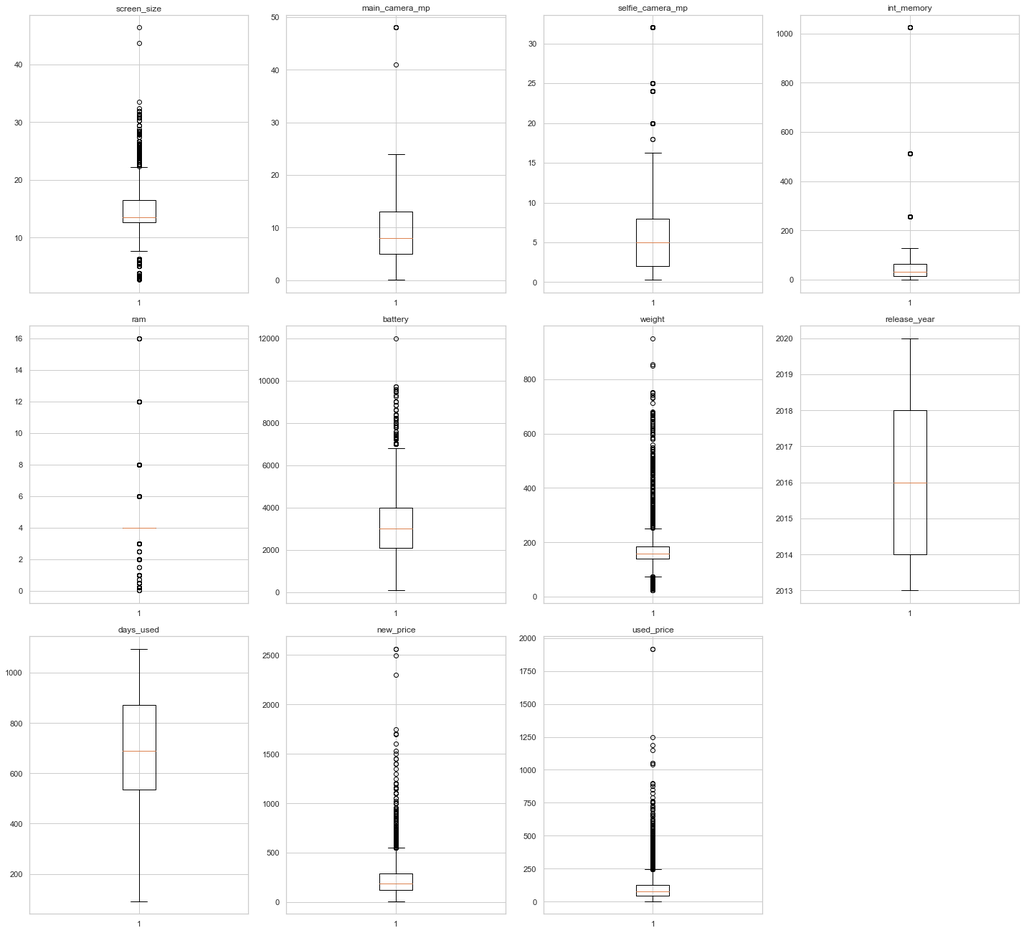

```python
# let's plot the boxplots of all columns to check for outliers
plt.figure(figsize=(20, 30))

for i, variable in enumerate(numeric_columns):
    plt.subplot(5, 4, i + 1)
    plt.boxplot(df[variable], whis=1.5)
    plt.tight_layout()
    plt.title(variable)

plt.show()
```

- all of them have outliers except `days_used` and `release_year`
- weight, Screen_size and ram have lower outliers.

## Outlier Treatment

Since `new_price` and `used_price` are highly skewd, I prefer to use log transformation for them.

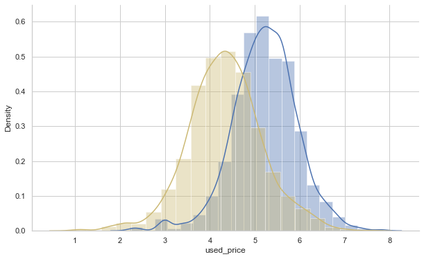

```python
plt.figure(figsize=(10,6))
fig = sns.distplot(np.log(df.new_price),color="b",bins=20)
fig = sns.distplot(np.log(df.used_price),color="y",bins=20)
sns.despine();
```

it seems that Log transformation is helpful in reducing the skewness. the blue one is related to new_price and yellow is related to used_price. I'll transform both and create new columns for those:

```python
df['log_new_price']=np.log(df.new_price)
df['log_used_price']=np.log(df.used_price)
df= df.drop(['new_price','used_price'], axis=1)
df
```

|  | brand_name | os | screen_size | main_camera_mp | selfie_camera_mp | int_memory | ram | battery | weight | release_year | days_used | 4_5g | log_new_price | log_used_price |
| --- | --- | --- | --- | --- | --- | --- | --- | --- | --- | --- | --- | --- | --- | --- |
| 0 | Honor | Android | 23.970 | 13.000 | 5.000 | 64.000 | 3.000 | 3020.000 | 146.000 | 2020 | 127 | 4g | 4.715 | 4.465 |
| 1 | Honor | Android | 28.100 | 13.000 | 16.000 | 128.000 | 8.000 | 4300.000 | 213.000 | 2020 | 325 | 4g | 5.519 | 5.084 |
| 2 | Honor | Android | 24.290 | 13.000 | 8.000 | 128.000 | 8.000 | 4200.000 | 213.000 | 2020 | 162 | 4g | 5.885 | 5.593 |
| 3 | Honor | Android | 26.040 | 13.000 | 8.000 | 64.000 | 6.000 | 7250.000 | 480.000 | 2020 | 345 | 4g | 5.631 | 5.194 |
| 4 | Honor | Android | 15.720 | 13.000 | 8.000 | 64.000 | 3.000 | 5000.000 | 185.000 | 2020 | 293 | 4g | 4.948 | 4.642 |
| ... | ... | ... | ... | ... | ... | ... | ... | ... | ... | ... | ... | ... | ... | ... |
| 3566 | Asus | Android | 15.880 | 8.000 | 8.000 | 64.000 | 6.000 | 5000.000 | 190.000 | 2019 | 232 | 4g | 6.484 | 6.196 |
| 3567 | Asus | Android | 15.240 | 13.000 | 8.000 | 128.000 | 8.000 | 4000.000 | 200.000 | 2018 | 541 | 4g | 6.252 | 5.558 |
| 3568 | Alcatel | Android | 18.730 | 13.000 | 5.000 | 32.000 | 3.000 | 4000.000 | 165.000 | 2020 | 201 | 4g | 4.529 | 4.246 |
| 3569 | Alcatel | Android | 18.730 | 13.000 | 5.000 | 32.000 | 2.000 | 4000.000 | 160.000 | 2020 | 149 | 4g | 4.624 | 4.332 |
| 3570 | Alcatel | Android | 13.490 | 13.000 | 5.000 | 16.000 | 2.000 | 4000.000 | 168.000 | 2020 | 176 | 4g | 4.280 | 3.922 |

3571 rows × 14 columns

```python
def treat_outliers(df, col):
    """
    treats outliers in a variable
    col: str, name of the numerical variable
    df: dataframe
    col: name of the column
    """
    Q1 = df[col].quantile(0.25)  # 25th quantile
    Q3 = df[col].quantile(0.75)  # 75th quantile
    IQR = Q3 - Q1
    Lower_Whisker = Q1 - 1.5 * IQR
    Upper_Whisker = Q3 + 1.5 * IQR

    # all the values smaller than Lower_Whisker will be assigned the value of Lower_Whisker
    # all the values greater than Upper_Whisker will be assigned the value of Upper_Whisker
    df[col] = np.clip(df[col], Lower_Whisker, Upper_Whisker)

    return df


def treat_outliers_all(df, col_list):
    """
    treat outlier in all numerical variables
    col_list: list of numerical variables
    df: data frame
    """
    for c in col_list:
        if (c!='log_new_price')& (c!='log_used_price'):
            df= treat_outliers(df, c)

    return df
```

```python
# treating the outliers
numerical_col = df.select_dtypes(include=np.number).columns.tolist()
df= treat_outliers_all(df, numerical_col)
```

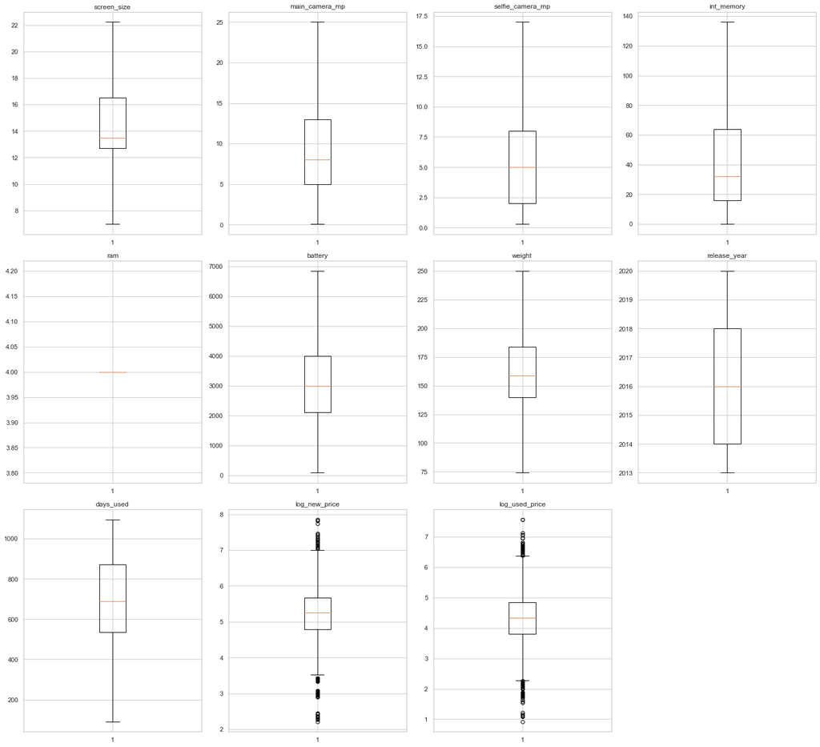

```python
#all of outliers have been treated but log_new_price and log_used_price
plt.figure(figsize=(20, 30))

for i, variable in enumerate(numerical_col):
    plt.subplot(5, 4, i + 1)
    plt.boxplot(df[variable], whis=1.5)
    plt.tight_layout()
    plt.title(variable)

plt.show()
```